# VIS_assignment 01

Mengyao

2020/9/11

I would like to thank Taelor for making such a great example posted on Github.

# Load packages

```r
library(tidyverse)
library(ggplot2)
library(knitr)
```

# Load data

As I had connection issue to get data directly from census, I tried to download three tables from the website and combined them. My analysis is based on 5-year American Community Survey of tracts in Middlesex County, Massachusetts in 2018.

I downloaded 1 zippd file named Means of transportation to work by class of workers.zip from data.census.gov. The zipped file contains three files:

1. The dataset (Means of transportation to work by class of workers_data.csv)
2. A list of variable names and descriptions (Means of transportation to work by class of workers_var.csv)
3. A description of the data source (Means of transportation to work by class of workers_data.txt)

```r
unzip("Means of transportation to work by class of workers.zip")
tran_variables <- read.csv("Means of transportation to work by class of workers_var.csv")
tran_data <- read.csv("Means of transportation to work by class of workers_data.csv", skip =1)
colnames(tran_data)
```

# Choosing variables

```r
data_commute <- tran_data %>%
  mutate(population =`Estimate..Total`,
         pct_car = `Estimate..Total..Car..truck..or.van...drove.alone`/`Estimate..Total`,
         pct_pub_trans = `Estimate..Total..Public.transportation..excluding.taxicab.`/`Estimate..Total`)%>%
  mutate(geoid = substr(id, 10, 20)) %>%
  select(geoid, population, pct_car, pct_pub_trans)
data_commute
```

# Load the 2nd dataset about income

```r
unzip("Income.zip")
income_variables <- read.csv("income_vars.csv")
income_data <- read.csv("income_data.csv", skip =1)
colnames(tran_data)
```

The table is based on 5-year American Community Survey of tracts in Middlesex County, Massachusetts in 2018. I want these variables from the table: 1. Whether foreign residents are richer (Categorical) 2. The median income (Continuous)

```r
data_income <- income_data %>%
  mutate(median_income = `Estimate..Median.income.in.the.past.12.months.....Total`,
         rich_foreign = `Estimate..Median.income.in.the.past.12.months.....Total..Foreign.born` > `Estimate..Median.income.in.the.past.12.months.....Total..Born.in.state.of.residence`)%>%
  mutate(geoid = substr(id, 10, 20)) %>%
  select(geoid, median_income, rich_foreign)
data_income
```

# Load the 3rd dataset about race

```r
unzip("Race.zip")
race_variables <- read.csv("race_vars.csv")
race_data <- read.csv("race_data.csv", skip =1)
colnames(race_data)
```

The table is based on 5-year American Community Survey of tracts in Middlesex County, Massachusetts in 2018. I want this variable from the table: 1. The majority race of the tract (Categorical)

```r
data_race <- race_data %>%
  mutate(majority_race = case_when(
    `Estimate..Total..White.alone`/`Estimate..Total` > 0.5 ~ "white",
    `Estimate..Total..Black.or.African.American.alone`/`Estimate..Total` > 0.5 ~ "black",
    `Estimate..Total..Asian.alone`/`Estimate..Total` >0.5 ~ "asian",
    (`Estimate..Total..White.alone`/`Estimate..Total`+`Estimate..Total..Black.or.African.American.alone`+`Estimate..Total..Asian.alone`+`Estimate..Total..White.alone`)/`Estimate..Total` < 0.5 ~ "other", TRUE ~ "None"))%>%
  mutate(geoid = substr(id, 10, 20)) %>%
  select(geoid, majority_race)
data_race
```

# Join data

This dataset includes 318 tracts. The first ten rows are presented here as a formatted table.

```r
all_data_01 <- inner_join(data_commute, data_income, by="geoid")
all_data <- inner_join(all_data_01, data_race, by="geoid")
knitr::kable(all_data[1:10,])
```

| geoid | population | pct_car | pct_pub_trans | median_income | rich_foreign | majority_race |
| --- | --- | --- | --- | --- | --- | --- |
| 25017352500 | 2249 | 0.1702979 | 0.3712761 | 52883 | TRUE | white |
| 25017352700 | 1204 | 0.3978405 | 0.1843854 | 31920 | FALSE | white |
| 25017353400 | 2000 | 0.1550000 | 0.3435000 | 40945 | TRUE | white |
| 25017356601 | 2414 | 0.6652858 | 0.1851698 | 50355 | TRUE | white |
| 25017357100 | 2057 | 0.6091395 | 0.1954302 | 63898 | TRUE | white |
| 25017357700 | 1731 | 0.5829001 | 0.2183709 | 45146 | FALSE | white |
| 25017373400 | 1809 | 0.6804865 | 0.1177446 | 64125 | TRUE | white |
| 25017368101 | 3477 | 0.7888985 | 0.0739143 | 49170 | FALSE | white |
| 25017368400 | 4393 | 0.5554291 | 0.0641930 | 22500 | FALSE | white |
| 25017369100 | 3144 | 0.8158397 | 0.0493003 | 51385 | FALSE | white |

```r
unique(all_data$majority_race)
```

```
## [1] "white" "None"  "asian"
```

# Plot 1

Plotting a majority of my variables

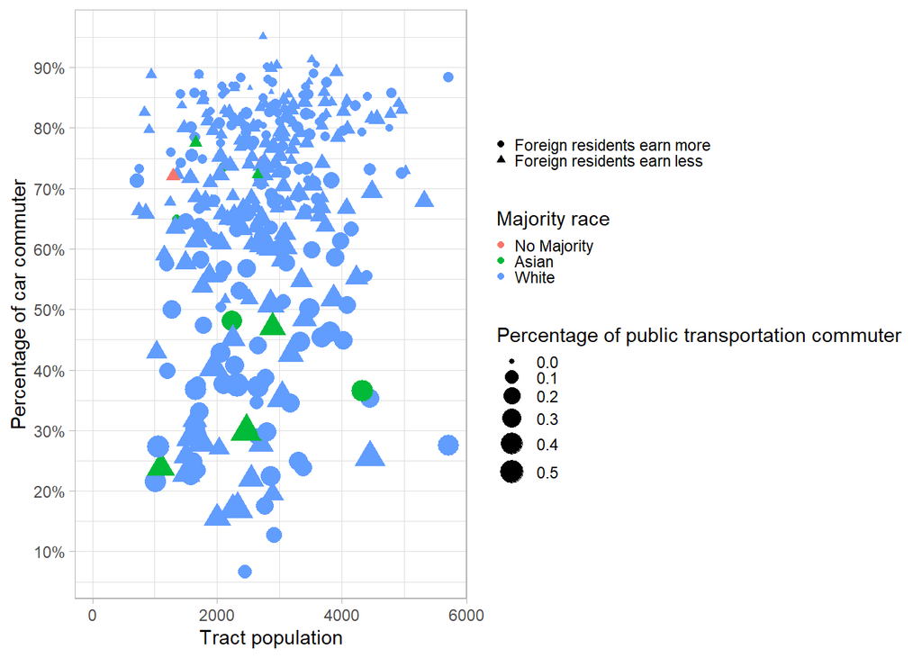

```r
ggplot(all_data,
       aes(x= population,
           y= pct_car,
           size = pct_pub_trans,
           color = majority_race,
           shape = rich_foreign)) +
  geom_point() +
  scale_x_continuous(name = "Tract population") +
  scale_y_continuous(name = "Percentage of car commuter",
                     breaks = seq(0,1,by=0.1),
                     labels = paste(seq(0,100,by=10), "%", sep=""))+
  scale_size_continuous(name ="Percentage of public transportation commuter") +
  scale_color_discrete(name = "Majority race",
                       labels = c("No Majority",
                                  "Asian",
                                  "White"))+
  scale_shape(name = element_blank(),
              labels = c("Foreign residents earn more", "Foreign residents earn less")) +
  theme_light() +
  theme(legend.key.size = unit(0.1, "cm"))
```

# Plot 2

Percentage of people using car for commute and median income

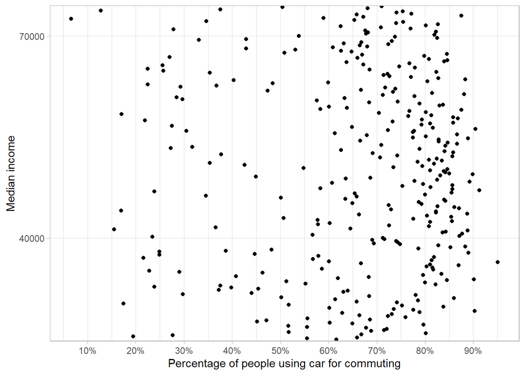

```r
ggplot(all_data,
       aes(x=pct_car,
           y=median_income)) +
  geom_point() +
  scale_x_continuous(name = "Percentage of people using car for commuting",
                     breaks = seq(0,1,by=0.1),
                     labels = paste(seq(0,100, by=10), "%", sep = ""))+
  scale_y_discrete(name = "Median income",
                   breaks = seq(10000, 110000, by=10000)) +
  theme_light()
```

# Plot 3

Majority race and percentage of people using public transportation for commute

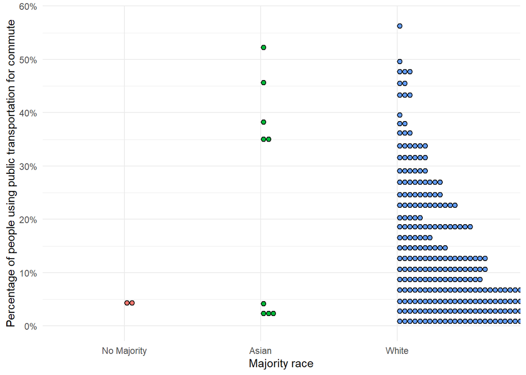

```r
ggplot(all_data,
       aes(x=majority_race,
           y=pct_pub_trans,
           fill= majority_race)) +
  geom_dotplot(binaxis = "y", dotsize = 0.5) +
  scale_x_discrete(name ="Majority race",
                   labels = c("No Majority", "Asian", "White")) +
  scale_y_continuous(name = "Percentage of people using public transportation for commute",
                     breaks = seq(0,1,by=0.1),
                     labels = paste(seq(0,100,by=10), "%", sep="")) +
  labs(fill = "Majority race") +
  scale_fill_discrete(name = "Majority race",
                      breaks = c("No Majority", "Asian", "White")) +
  theme_minimal()
```

# Plot 4

Heat map of richer foreigners, majority race and percentage of car commuters

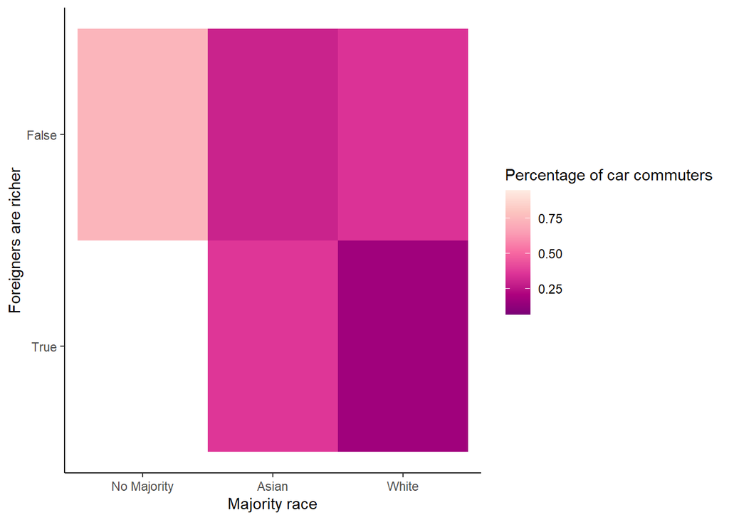

```r
ggplot(all_data,
       aes(x = majority_race,
           y = rich_foreign,
           fill = pct_car)) +
  geom_tile() +
  scale_x_discrete(name ="Majority race",
                   labels = c("No Majority", "Asian", "White")) +
  scale_y_discrete(name = "Foreigners are richer",
                   labels = c("True", "False")) +
  scale_fill_distiller(palette = "RdPu") +
  labs(fill = "Percentage of car commuters") +
  theme_classic()
```

# Plot 5

Scatter plot of percentage of car commuters and public transportation commuters

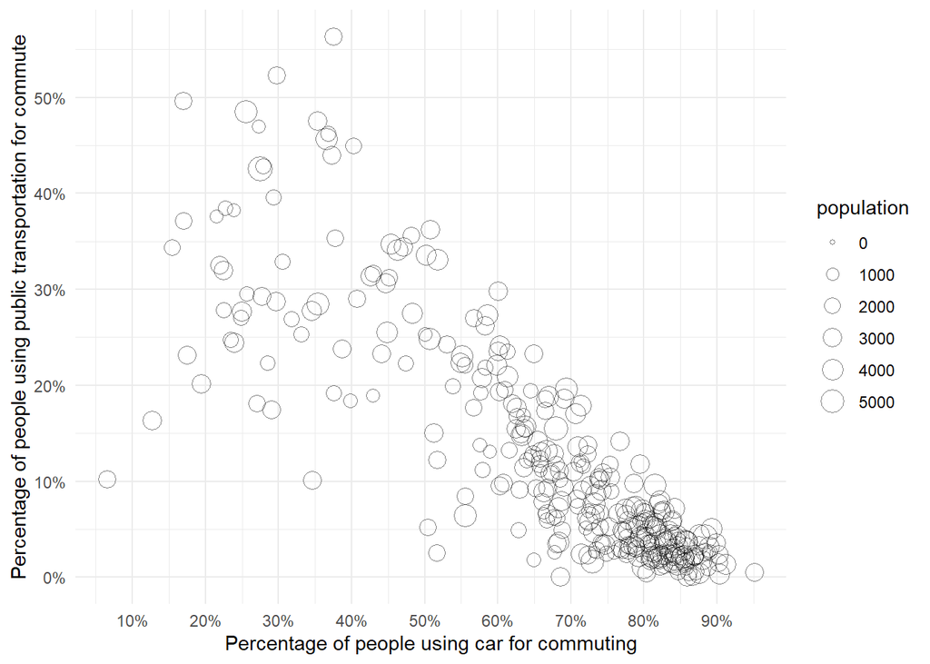

```r
ggplot(all_data,
       aes(x = pct_car,
           y = pct_pub_trans,
           size = population)) +
  geom_point (alpha = 0.5, shape = 21, color = "black") +
  scale_x_continuous(name = "Percentage of people using car for commuting",
                     breaks = seq(0,1,by=0.1),
                     labels = paste(seq(0,100, by=10), "%", sep = ""))+
  scale_y_continuous(name = "Percentage of people using public transportation for commute",
                     breaks = seq(0,1,by=0.1),
                     labels = paste(seq(0,100,by=10), "%", sep="")) +
  theme_minimal()
```

# Plot 6

Violin Plot of percentage of public transportation user and majority race

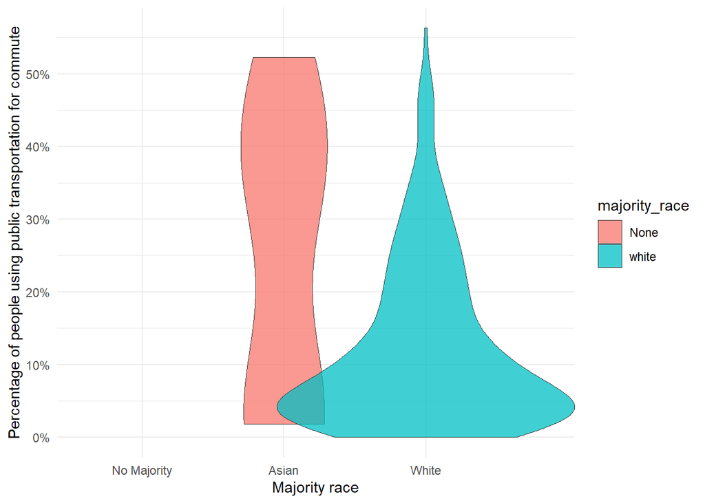

```r
ggplot(all_data,
       aes(x = majority_race,
           y = pct_pub_trans,
           fill = majority_race)) +
  geom_violin(width = 2.1, size = 0.2, alpha = 0.75) +
  scale_x_discrete(name ="Majority race",
                   labels = c("No Majority", "Asian", "White")) +
  scale_y_continuous(name = "Percentage of people using public transportation for commute",
                     breaks = seq(0,1,by=0.1),
                     labels = paste(seq(0,100,by=10), "%", sep="")) +
  theme_minimal()
```

# Plot 7

Box plot of percentage of public transportation user and whether foreigner is richer

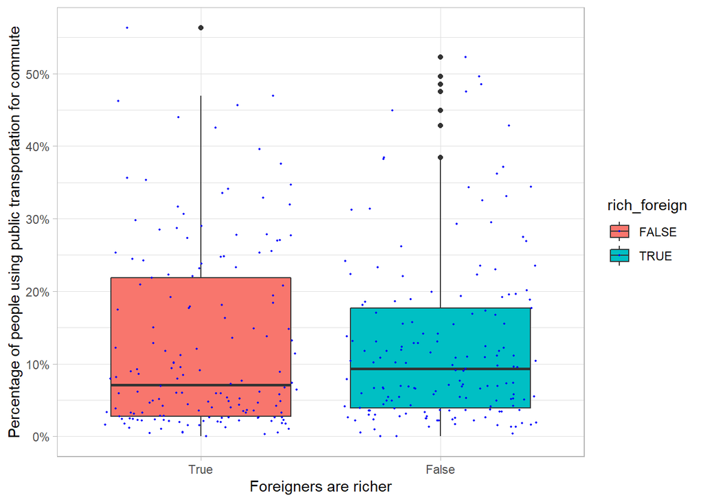

```r
ggplot(all_data,
      aes(x = rich_foreign,
          y = pct_pub_trans,
          fill = rich_foreign)) +
  geom_boxplot() +
  scale_x_discrete(name = "Foreigners are richer",
                   labels = c("True", "False")) +
  scale_y_continuous(name = "Percentage of people using public transportation for commute",
                     breaks = seq(0,1,by=0.1),
                     labels = paste(seq(0,100,by=10), "%", sep="")) +
  geom_jitter(color = "blue", size = 0.4, alpha = 0.9) +
  theme_light()
```

# Plot 8

Area chart of percentage of residents that use car to commute

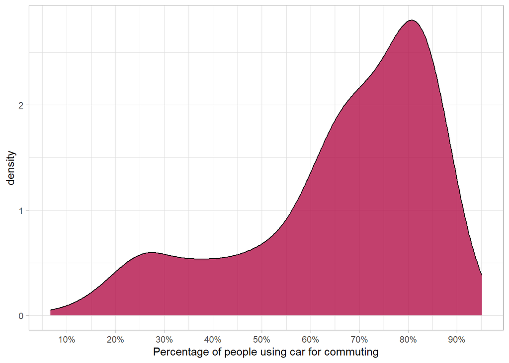

```r
ggplot(all_data,
       aes(x = pct_car)) +
  geom_density(fill = "#b31049", alpha = 0.8) +
  scale_x_continuous(name = "Percentage of people using car for commuting",
                     breaks = seq(0,1,by=0.1),
                     labels = paste(seq(0,100, by=10), "%", sep = ""))+
  theme_light()
```

# Plot 9

Majority race and median income

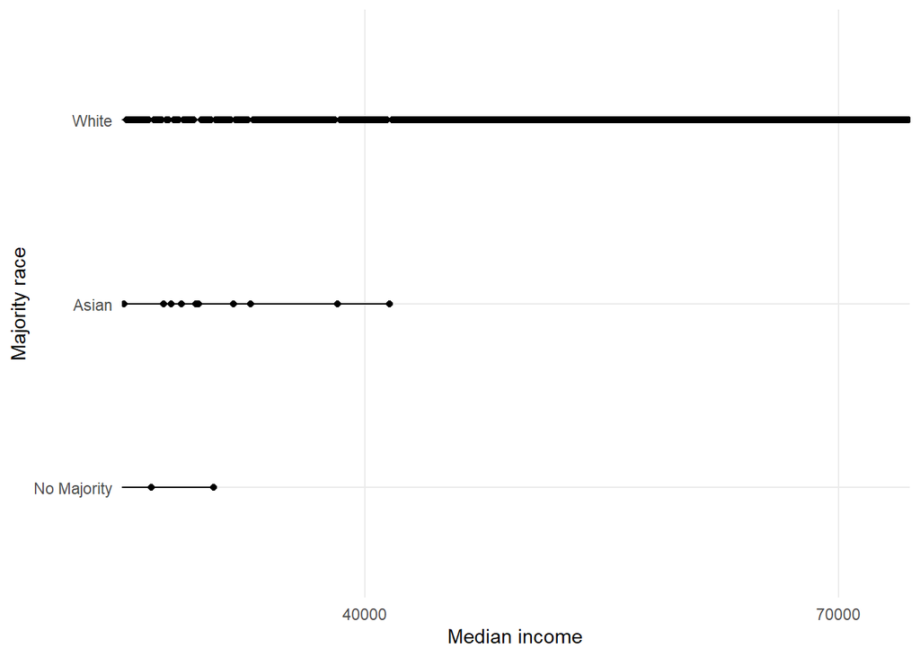

```r
ggplot(all_data,
       aes(x = median_income,
           y = majority_race)) +
  geom_point() +
  geom_segment(aes(x=0,
                   xend = median_income,
                   y = majority_race,
                   yend = majority_race)) +
  scale_x_discrete(name = "Median income",
                     breaks = seq(10000, 110000, by=10000)) +
  scale_y_discrete(name ="Majority race",
                   labels = c("No Majority", "Asian", "White")) +
  theme_minimal()
```

# Plot 10

Stacked bar chart of majority race and population

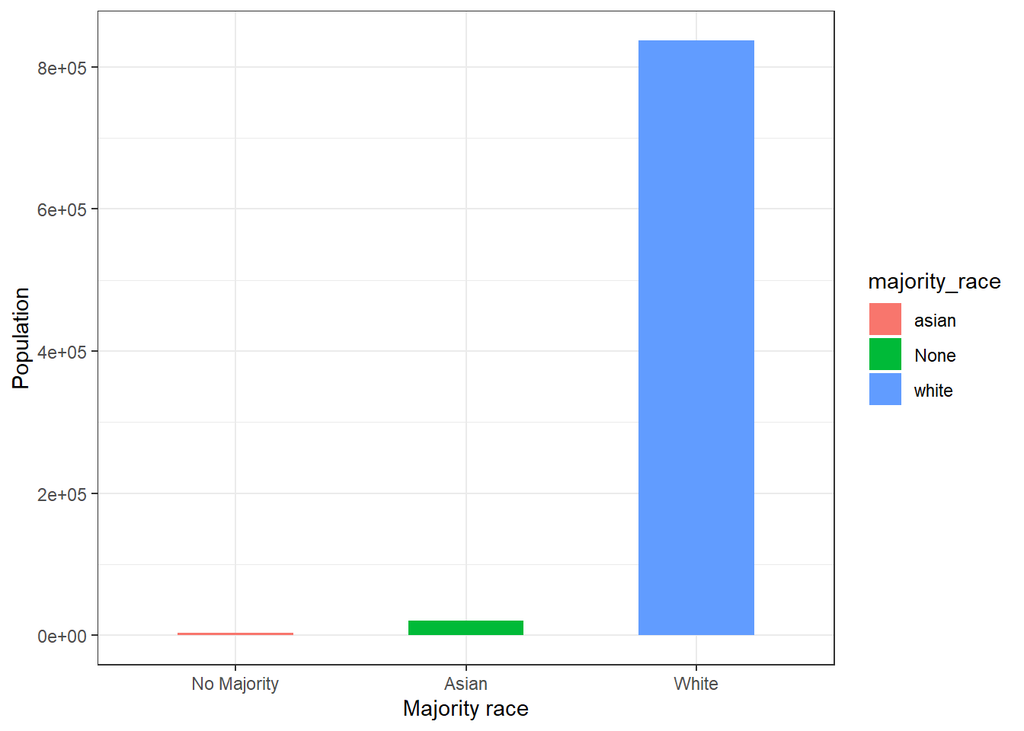

```r
ggplot(all_data,
       aes(x = majority_race,
           y = population,
           fill = majority_race)) +
  geom_bar(stat = "identity", width = 0.5) +
  scale_x_discrete(name ="Majority race",
                   labels = c("No Majority", "Asian", "White")) +
  scale_y_continuous(name = "Population") +
  theme_bw()
```